In this work, using the used car sales dataset from the cars_24 website, we will determine: 1) The most popular car brand and try to find out the reason for its popularity; 2) Find cars whose prices are less predictable than others; 3) Find out the type of data distribution and perform A / B testing; 4) Let's describe a liquid car for purchase; 5) Using the machine learning model, we will find the data columns that most affect the price of the car.

1. Car Name: The name or model of the car.
2. Distance: The distance already travelled by the car.
3. Year Bought: The year when the car was purchased.
4. Previous Owners: The number of previous owners of the car.
5. RTO Location: The location of the Regional Transport Office.
6. Transmission: The type of transmission (automatic or manual).
7. Car Type: The type of car (sedan, SUV, hatchback, luxury SUV, luxury sedan).
8. Fuel: The fuel used (petrol, diesel, CNG, etc.).
9. Price: The price of the car.

```python
pip install pandas
```

```python
pip install tensorflow
```

```python
pip install plotly
```

```python
pip install matplotlib
```

```python
import pandas as pd
import re
import statsmodels.api as sm
import matplotlib.pyplot as plt
from numpy import arange
from numpy import array
from scipy.stats import shapiro
from scipy.stats import mannwhitneyu
import random
from scipy.stats import kstest
import seaborn as sns
from sklearn.ensemble import RandomForestRegressor
from sklearn.metrics import mean_absolute_error
from tensorflow.keras.preprocessing.text import Tokenizer
from sklearn.model_selection import train_test_split
import plotly.express as px
```

```python
import warnings

warnings.filterwarnings('ignore')
```

## Data preprocessing

```python
data_cars = pd.read_csv(r'D:\data\cars_24_combined.csv')#Data import
data_cars
```

|  | Unnamed: 0 | Car Name | Year | Distance | Owner | Fuel | Location | Drive | Type | Price |
| --- | --- | --- | --- | --- | --- | --- | --- | --- | --- | --- |
| 0 | 0 | Maruti S PRESSO | 2022.0 | 3878 | 1 | PETROL | HR-98 | Manual | HatchBack | 514000 |
| 1 | 1 | Hyundai Xcent | 2018.0 | 32041 | 1 | PETROL | TN-22 | Manual | Sedan | 674000 |
| 2 | 2 | Tata Safari | 2021.0 | 96339 | 1 | DIESEL | TS-08 | Automatic | SUV | 1952000 |
| 3 | 3 | Maruti Vitara Brezza | 2019.0 | 51718 | 1 | DIESEL | WB-24 | Manual | SUV | 690000 |
| 4 | 4 | Tata Tiago | 2021.0 | 19811 | 1 | PETROL | HR-51 | Manual | HatchBack | 526000 |
| ... | ... | ... | ... | ... | ... | ... | ... | ... | ... | ... |
| 8010 | 8010 | Datsun Redi Go | 2018.0 | 11500 | 1 | PETROL | MH-01 | Manual | HatchBack | 292000 |
| 8011 | 8011 | Toyota YARIS | 2018.0 | 73393 | 2 | PETROL | KA-03 | Manual | Sedan | 534000 |
| 8012 | 8012 | Volkswagen Ameo | 2016.0 | 83810 | 2 | PETROL | UP-78 | Manual | Sedan | 424000 |
| 8013 | 8013 | Hyundai GRAND I10 NIOS | 2019.0 | 39162 | 1 | PETROL | CH-01 | Automatic | HatchBack | 685000 |
| 8014 | 8014 | Tata TIGOR | 2022.0 | 82009 | 2 | PETROL | MH-02 | Manual | Sedan | 392000 |

8015 rows × 10 columns

```python
print('The number of duplicates in the data is:',len(data_cars.loc[data_cars.duplicated()==True]))
```

```
The number of duplicates in the data is: 0
```

As you can see, the column Unnamed: 0 repeats the index values, I will delete it

```python
data_cars = data_cars.drop(columns='Unnamed: 0')#Delete unwanted column
data_cars
```

|  | Car Name | Year | Distance | Owner | Fuel | Location | Drive | Type | Price |
| --- | --- | --- | --- | --- | --- | --- | --- | --- | --- |
| 0 | Maruti S PRESSO | 2022.0 | 3878 | 1 | PETROL | HR-98 | Manual | HatchBack | 514000 |
| 1 | Hyundai Xcent | 2018.0 | 32041 | 1 | PETROL | TN-22 | Manual | Sedan | 674000 |
| 2 | Tata Safari | 2021.0 | 96339 | 1 | DIESEL | TS-08 | Automatic | SUV | 1952000 |
| 3 | Maruti Vitara Brezza | 2019.0 | 51718 | 1 | DIESEL | WB-24 | Manual | SUV | 690000 |
| 4 | Tata Tiago | 2021.0 | 19811 | 1 | PETROL | HR-51 | Manual | HatchBack | 526000 |
| ... | ... | ... | ... | ... | ... | ... | ... | ... | ... |
| 8010 | Datsun Redi Go | 2018.0 | 11500 | 1 | PETROL | MH-01 | Manual | HatchBack | 292000 |
| 8011 | Toyota YARIS | 2018.0 | 73393 | 2 | PETROL | KA-03 | Manual | Sedan | 534000 |
| 8012 | Volkswagen Ameo | 2016.0 | 83810 | 2 | PETROL | UP-78 | Manual | Sedan | 424000 |
| 8013 | Hyundai GRAND I10 NIOS | 2019.0 | 39162 | 1 | PETROL | CH-01 | Automatic | HatchBack | 685000 |
| 8014 | Tata TIGOR | 2022.0 | 82009 | 2 | PETROL | MH-02 | Manual | Sedan | 392000 |

8015 rows × 9 columns

```python
data_cars.info()
```

```
<class 'pandas.core.frame.DataFrame'>
RangeIndex: 8015 entries, 0 to 8014
Data columns (total 9 columns):
 #   Column    Non-Null Count  Dtype
---  ------    --------------  -----
 0   Car Name  8014 non-null   object
 1   Year      8014 non-null   float64
 2   Distance  8015 non-null   int64
 3   Owner     8015 non-null   int64
 4   Fuel      8015 non-null   object
 5   Location  7802 non-null   object
 6   Drive     8015 non-null   object
 7   Type      8015 non-null   object
 8   Price     8015 non-null   int64
dtypes: float64(1), int64(3), object(5)
memory usage: 563.7+ KB
```

```python
print('Location Column Lost Percentage:',(len(data_cars.loc[data_cars['Location'].isnull()==True])/len(data_cars))*100,'%')
```

```
Location Column Lost Percentage: 2.6575171553337493 %
```

```python
data_cars['Location'].unique()#View the unique values of the location column
```

```
array(['HR-98', 'TN-22', 'TS-08', 'WB-24', 'HR-51', 'MH-14', nan, 'UP-32',
       'HR-26', 'KA-04', 'PB-10', 'MH-48', 'GJ-05', 'GJ-27', 'MH-47',
       'KA-01', 'MH-01', 'GJ-01', 'PB-91', 'TN-19', 'UP-16', 'KA-19',
       'WB-02', 'DL-8C', 'DL-12', 'CH-01', 'KA-53', 'KA-02', 'TS-13',
       'KL-22', 'KL-09', 'HR-10', 'MH-05', 'TS-07', 'DL-11', 'MH-46',
       'MH-12', 'MH-04', 'KA-05', 'UP-14', 'HR-16', 'DL-9C', 'GJ-02',
       'RJ-02', 'BR-01', 'MH-02', 'DL-14', 'TN-02', 'KL-27', 'UP-78',
       'TN-14', 'KL-45', 'WB-90', 'AP-23', 'KL-41', 'PB-70', 'TN-09',
       'MH-03', 'DL-1C', 'MP-09', 'KL-01', 'KA-03', 'WB-20', 'DL-10',
       'DL-3C', 'KL-36', 'KA-09', 'TN-07', 'TS-10', 'RJ-36', 'HR-35',
       'PB-08', 'GJ-18', 'RJ-14', 'UP-37', 'GJ-38', 'HR-03', 'HR-52',
       'GJ-06', 'AP-29', 'TN-59', 'HR-36', 'GJ-32', 'GJ-08', 'TS-12',
       'WB-26', 'TN-06', 'KA-41', 'UP-65', 'MP-04', 'GJ-03', 'AP-10',
       'HR-13', 'DL-5C', 'KA-51', 'TN-58', 'DL-2C', 'MH-15', 'PB-07',
       'HR-30', 'KA-13', 'TN-12', 'MH-43', 'GJ-16', 'TS-09', 'MH-34',
       'KA-11', 'MH-40', 'MH-49', 'RJ-45', 'DL-7C', 'HR-20', 'TS-05',
       'KA-36', 'KA-25', 'PB-02', 'GJ-17', 'TN-10', 'TN-18', 'WB-12',
       'MH-09', 'MH-06', 'TN-37', 'TS-33', 'PB-12', 'TS-15', 'TS-11',
       'WB-08', 'KL-29', 'KA-16', 'MH-16', 'RJ-51', 'TS-19', 'TN-11',
       'TN-23', 'TS-29', 'DL-4C', 'TN-73', 'TN-57', 'WB-06', 'GJ-13',
       'KA-22', 'TN-85', 'DL-6C', 'AP-28', 'KA-06', 'KA-50', 'GJ-23',
       'TN-05', 'MH-29', 'AP-09', 'PB-13', 'TN-64', 'TN-55', 'HR-12',
       'GJ-04', 'HR-29', 'BR-31', 'MH-50', 'PB-65', 'KL-08', 'HR-76',
       'GJ-36', 'GJ-15', 'TN-03', 'PB-27', 'MH-31', 'MH-20', 'GJ-07',
       'KA-20', 'TN-01', 'TN-60', 'MP-15', 'KL-63', 'UP-53', 'TS-25',
       'HR-72', 'TN-38', 'KA-32', 'HR-34', 'GJ-21', 'HR-23', 'TS-03',
       'KA-26', 'TS-02', 'KL-82', 'TN-15', 'TS-28', 'RJ-21', 'HR-19',
       'GJ-19', 'HR-24', 'GJ-26', 'TS-06', 'TN-21', 'UP-27', 'TN-13',
       'HR-87', 'HR-14', 'TS-16', 'HR-85', 'GJ-12', 'WB-50', 'AP-07',
       'KA-55', 'KL-53', 'KL-75', 'KL-54', 'UP-72', 'TN-49', 'MH-35',
       'DL-13', '22-BH', 'RJ-28', 'RJ-13', 'TN-30', 'PB-39', 'UP-25',
       'KA-52', 'TN-68', 'KL-43', 'KA-17', 'HR-77', 'RJ-18', 'RJ-05',
       'UP-42', 'KA-14', 'BR-06', 'TN-43', 'AP-22', 'KL-40', 'TN-45',
       'WB-10', 'TN-20', 'TN-40', 'MH-27', 'TN-04', 'MH-08', 'UP-21',
       'MH-10', 'PB-19', 'AP-13', 'TN-69', 'RJ-47', 'KA-42', 'KA-12',
       'MP-19', 'TN-29', 'KL-07', 'TN-74', 'AP-11', 'RJ-23', 'TS-04',
       'MP-41', 'KL-02', 'TN-56', 'PB-09', 'KA-59', 'UP-85', 'MH-18',
       'UP-62', 'WB-44', 'TN-33', 'TN-72', 'UP-80', 'KA-43', 'MP-48',
       'KL-39', 'GJ-10', 'MH-44', 'KA-30', 'MP-05', 'TN-31', 'UP-40',
       'RJ-20', 'KA-63', 'RJ-41', 'PB-23', 'TN-77', 'UP-52', 'UP-15',
```

[output cut: 8 more lines]

```
       'KA-47', 'KL-47', 'UP-33', 'PB-03', 'TS-17', 'AP-39', 'KA-68',
       'KL-11', 'KL-66', 'TN-78', 'WB-42', 'KA-34', 'TN-63', 'KL-18',
       'KA-64', 'KL-17', 'MP-20', 'TS-36', 'TS-30', 'KA-65', 'MP-37',
       'WB-98', 'GJ-31', 'KL-14', 'TN-25', 'TN-91', 'WB-30', 'WB-66',
       'HR-02', 'PB-56', 'MP-16', 'TN-39', 'KL-32', 'HR-70', 'PB-29',
       'AP-30', 'WB-32', 'WB-38', 'UP-43', 'PB-11', 'KA-08', 'TN-66',
       'GJ-30', 'KL-33', 'KA-21', 'TN-81', 'AP-01', 'KA-29', 'KL-64',
       'KL-04', 'MH-17', 'TN-90', 'MH-24', 'KL-24', 'KL-25', 'UP-41',
       'TS-23', 'PB-28', 'KA-35', 'KL-03', 'KL-16', 'HR-06', 'KL-80',
       'UP-44', 'HR-50', 'KA-46', 'PB-32', 'KA-27', 'TN-52', 'TN-32',
       'TN-50', 'TS-32', 'BR-09', 'HR-80', 'KL-42', 'KL-34', 'UP-70',
       'KL-55', 'TN-67', 'KA-28', 'MH-13', 'RJ-06', 'RJ-27', 'KL-37',
       'KA-18', 'HR-05', 'TN-48', 'KA-40', 'MP-12', 'HR-22', 'UP-83',
       'TN-70', 'HR-21', 'KL-72', 'TS-18', 'RJ-53', 'PB-87', 'MH-32',
       'HR-79', 'PB-46'], dtype=object)
```

The number of locations is too large for such a dataset to be able to analyze by location, in some locations the statistics will be insufficient

```python
data_cars = data_cars.drop(columns='Location')
```

```python
data_cars = data_cars.dropna()#Remove gaps since it's 1 column
data_cars.info()
```

```
<class 'pandas.core.frame.DataFrame'>
Int64Index: 8014 entries, 0 to 8014
Data columns (total 8 columns):
 #   Column    Non-Null Count  Dtype
---  ------    --------------  -----
 0   Car Name  8014 non-null   object
 1   Year      8014 non-null   float64
 2   Distance  8014 non-null   int64
 3   Owner     8014 non-null   int64
 4   Fuel      8014 non-null   object
 5   Drive     8014 non-null   object
 6   Type      8014 non-null   object
 7   Price     8014 non-null   int64
dtypes: float64(1), int64(3), object(4)
memory usage: 563.5+ KB
```

```python
data_cars['Year'].unique()
```

```
array([2022., 2018., 2021., 2019., 2017., 2012., 2015., 2014., 2016.,
       2010., 2011., 2013., 2020., 2023.])
```

```python
data_cars = data_cars.assign(Year=lambda d: d['Year'].astype(int))#Converting a column to an integer data type
data_cars.info()
```

```
<class 'pandas.core.frame.DataFrame'>
Int64Index: 8014 entries, 0 to 8014
Data columns (total 8 columns):
 #   Column    Non-Null Count  Dtype
---  ------    --------------  -----
 0   Car Name  8014 non-null   object
 1   Year      8014 non-null   int32
 2   Distance  8014 non-null   int64
 3   Owner     8014 non-null   int64
 4   Fuel      8014 non-null   object
 5   Drive     8014 non-null   object
 6   Type      8014 non-null   object
 7   Price     8014 non-null   int64
dtypes: int32(1), int64(3), object(4)
memory usage: 532.2+ KB
```

```python
data_cars['Year'].unique()
```

```
array([2022, 2018, 2021, 2019, 2017, 2012, 2015, 2014, 2016, 2010, 2011,
       2013, 2020, 2023])
```

```python
data_cars['Car Name'].unique()
```

```
array(['Maruti S PRESSO', 'Hyundai Xcent', 'Tata Safari',
       'Maruti Vitara Brezza', 'Tata Tiago', 'Maruti Swift',
       'Hyundai i20', 'Renault Kwid', 'Hyundai Grand i10', 'Maruti IGNIS',
       'Honda Brio', 'Hyundai Elite i20', 'Honda City', 'Maruti Baleno',
       'Honda WR-V', 'Honda Amaze', 'Maruti Alto 800', 'Maruti Celerio',
       'Ford Ecosport', 'Maruti Ciaz', 'Datsun Redi Go', 'Tata TIAGO NRG',
       'Hyundai Santro Xing', 'Ford FREESTYLE', 'Maruti Dzire',
       'Maruti Alto', 'Hyundai NEW SANTRO', 'Maruti Alto K10',
       'Ford Endeavour', 'Maruti Swift Dzire', 'Maruti Wagon R 1.0',
       'Hyundai GRAND I10 NIOS', 'Maruti Celerio X',
       'Toyota URBAN CRUISER', 'Mahindra XUV500', 'Hyundai Verna',
       'Hyundai VENUE', 'Tata NEXON', 'Mahindra KUV 100 NXT',
       'Toyota YARIS', 'Mahindra XUV 3OO', 'Renault TRIBER',
       'Hyundai Tucson New', 'Mahindra TUV300', 'Toyota Glanza',
       'Maruti Eeco', 'Renault Duster', 'Hyundai i10', 'Nissan MAGNITE',
       'KIA SONET', 'Maruti Ertiga', 'Honda Jazz', 'KIA SELTOS',
       'Volkswagen Ameo', 'Renault Kiger', 'Honda Accord',
       'Hyundai NEW I20', 'Tata ALTROZ', 'Maruti A Star', 'Maruti Ritz',
       'Nissan Micra', 'Hyundai Eon', 'Hyundai Creta', 'Mahindra Bolero',
       'Toyota Etios Liva', 'Maruti New Wagon-R', 'Nissan Micra Active',
       'Tata Harrier', 'Tata TIGOR', 'Tata PUNCH', 'Volkswagen Polo',
       'Toyota Camry', 'Toyota Corolla Altis', 'Honda Civic',
       'Volkswagen Vento', 'Maruti S Cross', 'Skoda Octavia',
       'Hyundai i20 Active', 'Hyundai New Elantra', 'Honda BR-V',
       'Hyundai AURA', 'Mahindra Thar', 'Maruti Zen Estilo',
       'Hyundai NEW I20 N LINE', 'Tata Hexa', 'Maruti XL6', 'Honda CRV',
       'Toyota Innova', 'Skoda Rapid', 'Datsun Go',
       'Maruti Wagon R Stingray', 'Volkswagen TIGUAN', 'Toyota Etios',
       'Tata Zest', 'Ford New Figo', 'Mahindra Kuv100', 'Skoda SLAVIA',
       'Mahindra Scorpio', 'Nissan Terrano', 'Volkswagen TAIGUN',
       'Renault Captur', 'Mahindra XUV700', 'Hyundai Sonata',
       'Mahindra BOLERO NEO', 'Maruti BREZZA', 'Datsun Go Plus',
       'Hyundai ALCAZAR', 'BMW 3 Series', 'Jeep Compass',
       'Toyota Innova Crysta', 'KIA CARENS', 'Skoda KUSHAQ',
       'Volkswagen Jetta', 'Renault Pulse', 'Ford Figo Aspire',
       'Maruti Wagon R', 'Mahindra TUV 300 PLUS', 'MG HECTOR PLUS',
       'Tata Bolt', 'MG HECTOR', 'Volkswagen T-ROC', 'Maruti OMNI E',
       'Jeep GRAND CHEROKEE', 'Toyota Fortuner', 'Mahindra MARAZZO',
       'Nissan Sunny'], dtype=object)
```

I will check if there are cars starting with a different letter, if there are duplicates with an error

```python
data_cars.loc[data_cars['Car Name'].str.contains(r"cent")]
```

|  | Car Name | Year | Distance | Owner | Fuel | Drive | Type | Price |
| --- | --- | --- | --- | --- | --- | --- | --- | --- |
| 1 | Hyundai Xcent | 2018 | 32041 | 1 | PETROL | Manual | Sedan | 674000 |
| 163 | Hyundai Xcent | 2015 | 40791 | 2 | PETROL | Manual | Sedan | 444000 |
| 401 | Hyundai Xcent | 2018 | 42266 | 2 | PETROL | Manual | Sedan | 547000 |
| 413 | Hyundai Xcent | 2018 | 31133 | 1 | PETROL | Manual | Sedan | 568000 |
| 750 | Hyundai Xcent | 2014 | 77696 | 1 | PETROL | Manual | Sedan | 585000 |
| 806 | Hyundai Xcent | 2014 | 8767 | 1 | PETROL | Manual | Sedan | 990000 |
| 874 | Hyundai Xcent | 2018 | 8828 | 1 | PETROL | Automatic | Sedan | 892250 |
| 967 | Hyundai Xcent | 2017 | 58132 | 1 | PETROL | Automatic | Sedan | 788000 |
| 1059 | Hyundai Xcent | 2014 | 24934 | 1 | PETROL | Manual | Sedan | 711000 |
| 1276 | Hyundai Xcent | 2017 | 95666 | 1 | PETROL | Manual | Sedan | 420000 |
| 1284 | Hyundai Xcent | 2019 | 32457 | 1 | PETROL | Manual | Sedan | 842000 |
| 1544 | Hyundai Xcent | 2015 | 114678 | 1 | PETROL | Manual | Sedan | 617000 |
| 1614 | Hyundai Xcent | 2015 | 41544 | 2 | PETROL | Manual | Sedan | 326000 |
| 1666 | Hyundai Xcent | 2015 | 75360 | 1 | PETROL | Manual | Sedan | 401000 |
| 1707 | Hyundai Xcent | 2014 | 57000 | 1 | PETROL | Manual | Sedan | 340000 |
| 1712 | Hyundai Xcent | 2019 | 58973 | 1 | PETROL | Manual | Sedan | 334000 |
| 2211 | Hyundai Xcent | 2015 | 105339 | 1 | DIESEL | Manual | Sedan | 708000 |
| 2621 | Hyundai Xcent | 2017 | 65109 | 1 | PETROL | Manual | Sedan | 536000 |
| 2735 | Hyundai Xcent | 2015 | 99625 | 1 | CNG | Manual | Sedan | 681000 |
| 3420 | Hyundai Xcent | 2017 | 43185 | 1 | PETROL | Manual | Sedan | 594800 |
| 3839 | Hyundai Xcent | 2014 | 68677 | 1 | PETROL | Manual | Sedan | 379000 |
| 3965 | Hyundai Xcent | 2018 | 66790 | 2 | PETROL | Manual | Sedan | 321000 |
| 4013 | Hyundai Xcent | 2017 | 63055 | 1 | PETROL | Manual | Sedan | 393000 |
| 4107 | Hyundai Xcent | 2016 | 32043 | 1 | PETROL | Manual | Sedan | 691000 |
| 4195 | Hyundai Xcent | 2016 | 99067 | 2 | PETROL | Manual | Sedan | 351000 |
| 4238 | Hyundai Xcent | 2016 | 87210 | 1 | CNG | Manual | Sedan | 446000 |
| 4463 | Hyundai Xcent | 2018 | 68177 | 1 | PETROL | Manual | Sedan | 796000 |
| 4614 | Hyundai Xcent | 2014 | 39761 | 1 | PETROL | Manual | Sedan | 321000 |
| 4746 | Hyundai Xcent | 2018 | 63498 | 1 | PETROL | Automatic | Sedan | 933000 |
| 4790 | Hyundai Xcent | 2018 | 19877 | 1 | PETROL | Automatic | Sedan | 897000 |
| 4978 | Hyundai Xcent | 2017 | 42900 | 1 | PETROL | Automatic | Sedan | 889000 |
| 5091 | Hyundai Xcent | 2019 | 37432 | 1 | PETROL | Manual | Sedan | 537000 |
| 5248 | Hyundai Xcent | 2019 | 48347 | 1 | DIESEL | Manual | Sedan | 272000 |
| 5279 | Hyundai Xcent | 2015 | 58483 | 1 | PETROL | Automatic | Sedan | 834000 |
| 5606 | Hyundai Xcent | 2014 | 17785 | 1 | PETROL | Automatic | Sedan | 1210000 |
| 5710 | Hyundai Xcent | 2014 | 43727 | 1 | PETROL | Manual | Sedan | 486000 |
| 6137 | Hyundai Xcent | 2018 | 119547 | 1 | CNG | Manual | Sedan | 492000 |
| 6161 | Hyundai Xcent | 2017 | 53751 | 1 | PETROL | Manual | Sedan | 477000 |
| 6383 | Hyundai Xcent | 2014 | 52927 | 1 | PETROL | Manual | Sedan | 665000 |
| 6514 | Hyundai Xcent | 2018 | 114715 | 1 | CNG | Manual | Sedan | 507000 |
| 6600 | Hyundai Xcent | 2018 | 12896 | 1 | PETROL | Manual | Sedan | 554000 |
| 6737 | Hyundai Xcent | 2017 | 78148 | 1 | PETROL | Automatic | Sedan | 441000 |
| 7020 | Hyundai Xcent | 2017 | 91910 | 1 | PETROL | Manual | Sedan | 695000 |
| 7100 | Hyundai Xcent | 2014 | 52255 | 2 | DIESEL | Manual | Sedan | 451000 |
| 7155 | Hyundai Xcent | 2014 | 94887 | 1 | PETROL | Manual | Sedan | 317000 |
| 7232 | Hyundai Xcent | 2015 | 101643 | 2 | DIESEL | Manual | Sedan | 310000 |
| 7422 | Hyundai Xcent | 2014 | 49493 | 1 | PETROL | Manual | Sedan | 380000 |
| 7606 | Hyundai Xcent | 2017 | 22424 | 1 | PETROL | Manual | Sedan | 612000 |
| 7651 | Hyundai Xcent | 2014 | 24103 | 1 | PETROL | Manual | Sedan | 603000 |
| 7729 | Hyundai Xcent | 2017 | 23420 | 1 | PETROL | Manual | Sedan | 505000 |

```python
data_cars.loc[data_cars['Car Name'].str.contains(r"orolla")]
```

|  | Car Name | Year | Distance | Owner | Fuel | Drive | Type | Price |
| --- | --- | --- | --- | --- | --- | --- | --- | --- |
| 325 | Toyota Corolla Altis | 2015 | 66362 | 3 | PETROL | Automatic | Lux_sedan | 860000 |
| 443 | Toyota Corolla Altis | 2017 | 96186 | 3 | CNG | Automatic | Lux_sedan | 944000 |
| 549 | Toyota Corolla Altis | 2014 | 65829 | 1 | PETROL | Automatic | Lux_sedan | 807000 |
| 599 | Toyota Corolla Altis | 2010 | 69278 | 2 | PETROL | Manual | Lux_sedan | 234000 |
| 887 | Toyota Corolla Altis | 2017 | 49543 | 1 | PETROL | Manual | Lux_sedan | 982000 |
| 1097 | Toyota Corolla Altis | 2018 | 101720 | 1 | DIESEL | Manual | Lux_sedan | 1065000 |
| 1560 | Toyota Corolla Altis | 2018 | 51848 | 2 | DIESEL | Manual | Lux_sedan | 1102000 |
| 2187 | Toyota Corolla Altis | 2011 | 100075 | 2 | PETROL | Manual | Lux_sedan | 394000 |
| 2190 | Toyota Corolla Altis | 2013 | 104563 | 2 | PETROL | Manual | Lux_sedan | 353000 |
| 2350 | Toyota Corolla Altis | 2013 | 56766 | 3 | PETROL | Manual | Lux_sedan | 434000 |
| 2431 | Toyota Corolla Altis | 2017 | 66207 | 1 | PETROL | Automatic | Lux_sedan | 1086000 |
| 2681 | Toyota Corolla Altis | 2018 | 66349 | 1 | PETROL | Automatic | Lux_sedan | 1289000 |
| 2868 | Toyota Corolla Altis | 2010 | 46034 | 1 | PETROL | Manual | Lux_sedan | 269000 |
| 2953 | Toyota Corolla Altis | 2018 | 54068 | 1 | PETROL | Manual | Lux_sedan | 927000 |
| 3309 | Toyota Corolla Altis | 2011 | 117499 | 2 | CNG | Manual | Lux_sedan | 293000 |
| 3395 | Toyota Corolla Altis | 2018 | 34339 | 2 | PETROL | Automatic | Lux_sedan | 1215000 |
| 3501 | Toyota Corolla Altis | 2011 | 82699 | 2 | PETROL | Manual | Lux_sedan | 366000 |
| 3611 | Toyota Corolla Altis | 2017 | 75836 | 1 | PETROL | Automatic | Lux_sedan | 1089000 |
| 4470 | Toyota Corolla Altis | 2014 | 95766 | 2 | PETROL | Automatic | Lux_sedan | 822000 |
| 4590 | Toyota Corolla Altis | 2014 | 102477 | 2 | PETROL | Automatic | Lux_sedan | 750000 |
| 4919 | Toyota Corolla Altis | 2011 | 53059 | 2 | CNG | Manual | Lux_sedan | 338000 |
| 4999 | Toyota Corolla Altis | 2010 | 70947 | 3 | DIESEL | Manual | Lux_sedan | 272000 |
| 5057 | Toyota Corolla Altis | 2011 | 63980 | 2 | PETROL | Manual | Lux_sedan | 325000 |
| 5198 | Toyota Corolla Altis | 2011 | 66466 | 2 | PETROL | Manual | Lux_sedan | 379000 |
| 5592 | Toyota Corolla Altis | 2016 | 91242 | 2 | PETROL | Automatic | Lux_sedan | 846000 |
| 5622 | Toyota Corolla Altis | 2012 | 63140 | 1 | PETROL | Automatic | Lux_sedan | 496000 |
| 6000 | Toyota Corolla Altis | 2015 | 63857 | 1 | PETROL | Automatic | Lux_sedan | 807000 |
| 6114 | Toyota Corolla Altis | 2015 | 60408 | 2 | PETROL | Automatic | Lux_sedan | 879000 |
| 6197 | Toyota Corolla Altis | 2010 | 69700 | 2 | PETROL | Manual | Lux_sedan | 238000 |
| 6211 | Toyota Corolla Altis | 2014 | 98136 | 1 | DIESEL | Manual | Lux_sedan | 443000 |
| 6290 | Toyota Corolla Altis | 2017 | 97908 | 1 | PETROL | Automatic | Lux_sedan | 1009000 |
| 6620 | Toyota Corolla Altis | 2016 | 69981 | 2 | PETROL | Automatic | Lux_sedan | 957000 |
| 6767 | Toyota Corolla Altis | 2010 | 50952 | 1 | DIESEL | Manual | Lux_sedan | 445000 |
| 7282 | Toyota Corolla Altis | 2013 | 43285 | 2 | DIESEL | Manual | Lux_sedan | 416000 |
| 7691 | Toyota Corolla Altis | 2010 | 85954 | 2 | PETROL | Manual | Lux_sedan | 233600 |

No duplicates, no need to convert data, look at the unique values for the rest of the columns

```python
data_cars['Fuel'].unique()
```

```
array(['PETROL', 'DIESEL', 'CNG', 'LPG'], dtype=object)
```

```python
data_cars['Drive'].unique()
```

```
array(['Manual', 'Automatic'], dtype=object)
```

```python
data_cars['Type'].unique()
```

```
array(['HatchBack', 'Sedan', 'SUV', 'Lux_SUV', 'Lux_sedan'], dtype=object)
```

The Car Name column contains both the name and brand of the car, for convenience we will divide this data into 2 columns

```python
def find_first(text):#Car brand search function, since the first word in a sentence is the car brand, our function looks for the first word
    pattern = re.compile(r'\w+')
    return pattern.findall(text)[0]
```

```python
data_cars.loc[:,('Manufacturer')] = data_cars['Car Name'].apply(find_first)#apply the function
```

```python
data_cars#check
```

|  | Car Name | Year | Distance | Owner | Fuel | Drive | Type | Price | Manufacturer |
| --- | --- | --- | --- | --- | --- | --- | --- | --- | --- |
| 0 | Maruti S PRESSO | 2022 | 3878 | 1 | PETROL | Manual | HatchBack | 514000 | Maruti |
| 1 | Hyundai Xcent | 2018 | 32041 | 1 | PETROL | Manual | Sedan | 674000 | Hyundai |
| 2 | Tata Safari | 2021 | 96339 | 1 | DIESEL | Automatic | SUV | 1952000 | Tata |
| 3 | Maruti Vitara Brezza | 2019 | 51718 | 1 | DIESEL | Manual | SUV | 690000 | Maruti |
| 4 | Tata Tiago | 2021 | 19811 | 1 | PETROL | Manual | HatchBack | 526000 | Tata |
| ... | ... | ... | ... | ... | ... | ... | ... | ... | ... |
| 8010 | Datsun Redi Go | 2018 | 11500 | 1 | PETROL | Manual | HatchBack | 292000 | Datsun |
| 8011 | Toyota YARIS | 2018 | 73393 | 2 | PETROL | Manual | Sedan | 534000 | Toyota |
| 8012 | Volkswagen Ameo | 2016 | 83810 | 2 | PETROL | Manual | Sedan | 424000 | Volkswagen |
| 8013 | Hyundai GRAND I10 NIOS | 2019 | 39162 | 1 | PETROL | Automatic | HatchBack | 685000 | Hyundai |
| 8014 | Tata TIGOR | 2022 | 82009 | 2 | PETROL | Manual | Sedan | 392000 | Tata |

8014 rows × 9 columns

```python
data_cars['Manufacturer'].unique()
```

```
array(['Maruti', 'Hyundai', 'Tata', 'Renault', 'Honda', 'Ford', 'Datsun',
       'Toyota', 'Mahindra', 'Nissan', 'KIA', 'Volkswagen', 'Skoda',
       'BMW', 'Jeep', 'MG'], dtype=object)
```

```python
def find_car_name(text):#by the same principle we find the name of cars
    pattern = re.compile(r'\w+')
    return ' '.join(pattern.findall(text)[1:])
```

```python
data_cars.loc[:,('Name_car')] = data_cars['Car Name'].apply(find_car_name)
```

```python
data_cars = data_cars.drop(columns='Car Name')#Delete unnecessary column
data_cars
```

|  | Year | Distance | Owner | Fuel | Drive | Type | Price | Manufacturer | Name_car |
| --- | --- | --- | --- | --- | --- | --- | --- | --- | --- |
| 0 | 2022 | 3878 | 1 | PETROL | Manual | HatchBack | 514000 | Maruti | S PRESSO |
| 1 | 2018 | 32041 | 1 | PETROL | Manual | Sedan | 674000 | Hyundai | Xcent |
| 2 | 2021 | 96339 | 1 | DIESEL | Automatic | SUV | 1952000 | Tata | Safari |
| 3 | 2019 | 51718 | 1 | DIESEL | Manual | SUV | 690000 | Maruti | Vitara Brezza |
| 4 | 2021 | 19811 | 1 | PETROL | Manual | HatchBack | 526000 | Tata | Tiago |
| ... | ... | ... | ... | ... | ... | ... | ... | ... | ... |
| 8010 | 2018 | 11500 | 1 | PETROL | Manual | HatchBack | 292000 | Datsun | Redi Go |
| 8011 | 2018 | 73393 | 2 | PETROL | Manual | Sedan | 534000 | Toyota | YARIS |
| 8012 | 2016 | 83810 | 2 | PETROL | Manual | Sedan | 424000 | Volkswagen | Ameo |
| 8013 | 2019 | 39162 | 1 | PETROL | Automatic | HatchBack | 685000 | Hyundai | GRAND I10 NIOS |
| 8014 | 2022 | 82009 | 2 | PETROL | Manual | Sedan | 392000 | Tata | TIGOR |

8014 rows × 9 columns

## Data Acquaintance

```python
data_cars.groupby(['Name_car']).count().sort_values(by='Year', axis=0, ascending=False)[:10]['Year']
```

```
Name_car
Swift          593
Grand i10      451
Baleno         430
Elite i20      382
Wagon R 1 0    362
City           307
Celerio        245
Kwid           229
Alto 800       226
Amaze          205
Name: Year, dtype: int64
```

Let's look at the first top 10 cars

Some of the most popular cars are: Swift,Grand i10, Baleno

We will check the normality of the distribution of car prices and mileage so that we can test hypotheses in the future.

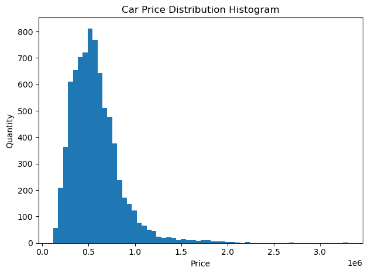

```python
fig, ax = plt.subplots()

# the histogram of the data
n, bins, patches = ax.hist(data_cars['Price'], 60, density=False)

# add a 'best fit' line

ax.set_xlabel('Price')
ax.set_ylabel('Quantity')
ax.set_title(r'Car Price Distribution Histogram')

# Tweak spacing to prevent clipping of ylabel
fig.tight_layout()
plt.show()
```

```python
data_cars['Price'].describe()
```

```
count    8.014000e+03
mean     5.748328e+05
std      2.650835e+05
min      1.190000e+05
25%      3.930000e+05
50%      5.350000e+05
75%      6.980000e+05
max      3.300000e+06
Name: Price, dtype: float64
```

```python
print('The median of the Price column is:',data_cars['Price'].median())
print('The mean of the Price column is:',data_cars['Price'].mean())
```

```
The median of the Price column is: 535000.0
The mean of the Price column is: 574832.8050910906
```

As we can see, the median is less than the average, this indicates the presence of large outliers in the price, I assume that expensive cars are rare in the used car market and these data are not outliers, this is a feature of the data.

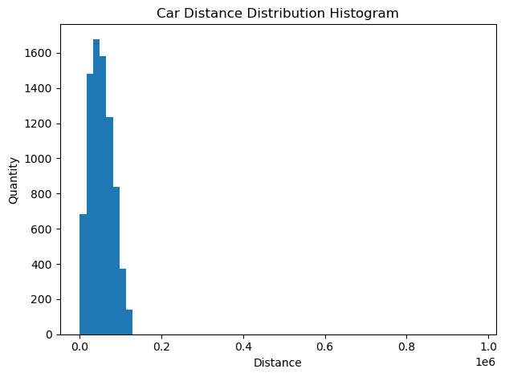

```python
fig, ax = plt.subplots()

# the histogram of the data
n, bins, patches = ax.hist(data_cars['Distance'], 60, density=False)

# add a 'best fit' line

ax.set_xlabel('Distance')
ax.set_ylabel('Quantity')
ax.set_title(r'Car Distance Distribution Histogram')

# Tweak spacing to prevent clipping of ylabel
fig.tight_layout()
plt.show()
```

```python
data_cars['Distance'].describe()
```

```
count      8014.000000
mean      52626.256676
std       29181.519800
min           0.000000
25%       30736.750000
50%       50369.500000
75%       71762.500000
max      971212.000000
Name: Distance, dtype: float64
```

```python
data_cars.loc[data_cars['Distance']==0]
```

[output not shown]

```python
data_cars.loc[data_cars['Distance']>500000]
```

[output not shown]

I noticed cars with mileage 0 and one of them had 2 owners and a car in 2016, most likely this is an outlier, delete these lines. Also, data with a distance greater than 500000 will be an outlier.

```python
data_cars = data_cars.drop(data_cars.loc[data_cars['Distance']==0].index)
data_cars.info()
```

[output not shown]

```python
data_cars = data_cars.drop(data_cars.loc[data_cars['Distance']>500000].index)
data_cars.info()
```

[output not shown]

Let's check for normal distribution of prices and distances.

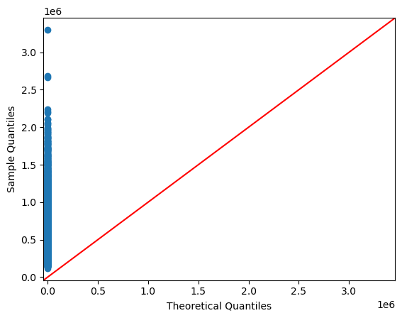

```python
fig = sm. qqplot (data_cars['Price'], line='45')#Building a qq-plot graph

plt.show()
```

```python
#perform Shapiro-Wilk test
shapiro(data_cars['Price'])
```

```
ShapiroResult(statistic=0.8904800415039062, pvalue=0.0)
```

According to the chart, it is difficult to conclude whether the price distribution is normal, we can only say that it looks like a Poisson distribution. After running a QQ-test (the points did not lie on the red straight line) and a Shapiro-Wilk test (p-value below 0.05, equal to zero) for normality, we can conclude that the car price column is not normally distributed. Let's take a look at the distribution of the population mean of the price column.

```python
#This loop splits the population of prices into subsamples of 500 and 3000 times, counting the average value of the subsamples and saves everything in an array mean_distribution
mean_distribution = []
for i in range(3000):
    mean = array(random.SystemRandom().sample(list(data_cars['Price']), 500)).mean()
    mean_distribution.append(mean)
```

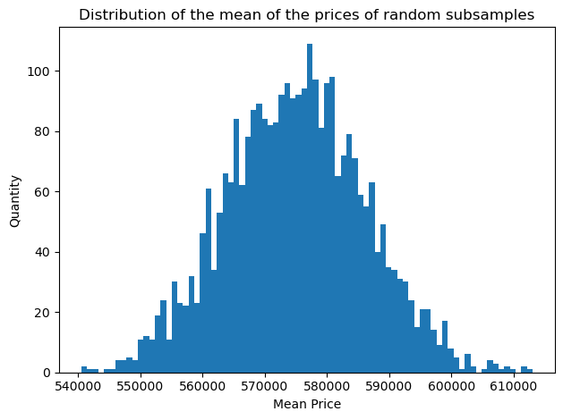

```python
fig, ax = plt.subplots()

# the histogram of the data
n, bins, patches = ax.hist(mean_distribution, 80, density=False)

# add a 'best fit' line

ax.set_xlabel('Mean Price')
ax.set_ylabel('Quantity')
ax.set_title(r'Distribution of the mean of the prices of random subsamples')

# Tweak spacing to prevent clipping of ylabel
fig.tight_layout()
plt.show()
```

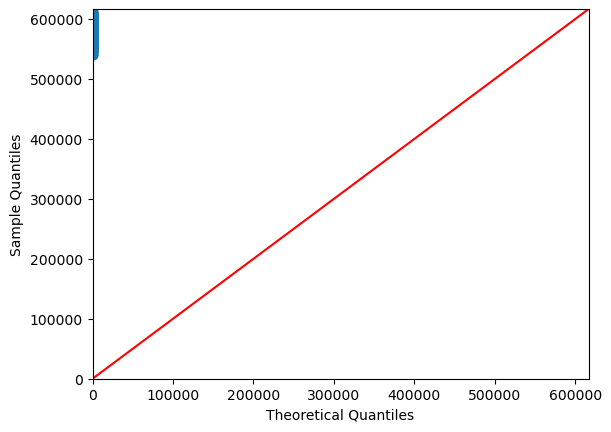

```python
fig = sm. qqplot (array(mean_distribution), line='45')

plt.show()
```

```python
shapiro(mean_distribution)
```

```
ShapiroResult(statistic=0.9992455840110779, pvalue=0.25401556491851807)
```

Let's check the distribution of the run distance for normality

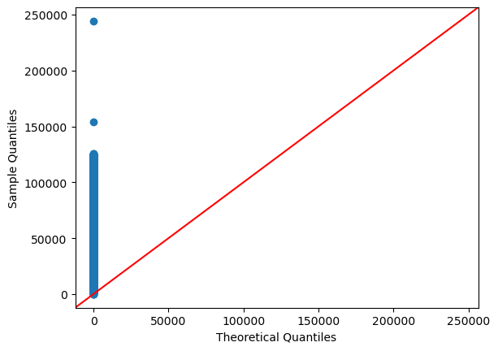

```python
fig = sm. qqplot (data_cars['Distance'], line='45')

plt.show()
```

```python
#perform Shapiro-Wilk test
shapiro(data_cars['Distance'])
```

```
ShapiroResult(statistic=0.9785762429237366, pvalue=5.038843594850093e-33)
```

These distances are not normally distributed, so we will also check the distribution of the average distance for normality, according to the same principle as before

```python
mean_distribution = []
for i in range(3000):
    mean = array(data_cars['Distance'].sample(500)).mean()
    mean_distribution.append(mean)
```

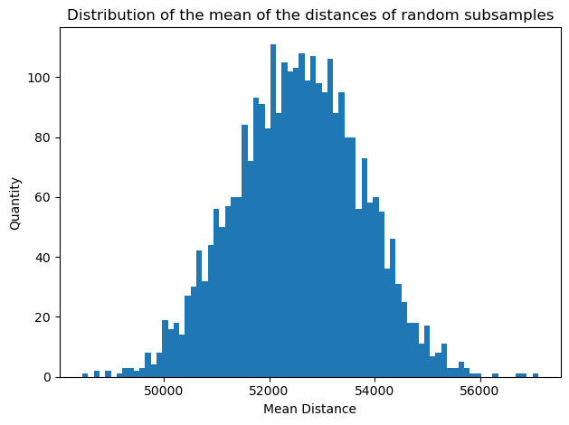

```python
fig, ax = plt.subplots()

# the histogram of the data
n, bins, patches = ax.hist(mean_distribution, 80, density=False)

# add a 'best fit' line

ax.set_xlabel('Mean Distance')
ax.set_ylabel('Quantity')
ax.set_title(r'Distribution of the mean of the distances of random subsamples')

# Tweak spacing to prevent clipping of ylabel
fig.tight_layout()
plt.show()
```

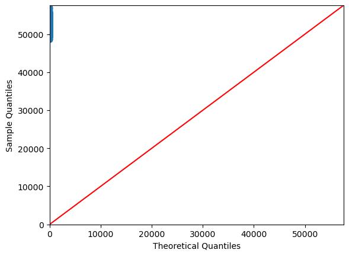

```python
fig = sm.qqplot(array(mean_distribution), line='45')

plt.show()
```

```python
#perform Shapiro-Wilk test
shapiro(mean_distribution)
```

```
ShapiroResult(statistic=0.9993082880973816, pvalue=0.3307148814201355)
```

Due to the fact that the QQ-test and the Shapiro-Wilk test diverge, another Kolmogorov-Smirnov test is applicable.

```python
kstest(mean_distribution, 'norm')#perform Kolmogorov-Smirnov test
```

```
KstestResult(statistic=1.0, pvalue=0.0, statistic_location=48456.332, statistic_sign=-1)
```

So in both cases (price and distance) we are dealing with non-normally distributed data, since the p-value is less than 0.05

Conclusion

There is an imbalance in the data on such columns as: Manufacturer - in this column 43% of the data is Maruti; Owner - in this column, 76.2% of the data is 1 owner; Fuel - in this column, 79.5% of the data is Petrol; Drive - 80.4% of the data is Manual; Type - 63.5% of the data is Hatchback. This means that it is difficult to compare distributions by conducting an A/B test due to unevenness (imbalance) and a correction for imbalance is necessary (for example, randomly sampling data from a larger class, then testing it 100-1000 times, the result is accepted with 5% accuracy).

## Data analysis

Let's build graphs and analyze the data, for this I wrote the functions below

```python
def pie_chart(column):
    vals = list(data_cars.groupby([column]).count().sort_values(by='Name_car', axis=0, ascending=False)['Name_car'])
    #Data preparation
    labels = data_cars.groupby([column]).count().sort_values(by='Name_car', axis=0, ascending=False).index
    #Label output
    num_of_tokens = len(list(data_cars.groupby([column]).count().sort_values(by='Year', axis=0, ascending=False)['Name_car']))
    #Name output
    explode = arange(0.15, 0.1, -(0.05/num_of_tokens))#Building pie chart
    fig, ax = plt.subplots()
    ax.set_title('Distribution pie chart in a column:'+column, y = 1.1)
    ax.pie(vals, labels=labels, autopct='%1.1f%%', shadow=True, explode=explode, wedgeprops={'lw':1, 'ls':'--','edgecolor':"k"}, rotatelabels=True)
    ax.axis("equal")
```

Since the manufacturer Maruti is the most voluminous, in order to find out the reason for its popularity, we will build comparative pie chart

```python
def pie_chart_for_Maruti(column):#Same function but for
    data_car = data_cars.loc[data_cars['Manufacturer']=='Maruti']
    vals = list(data_car.groupby([column]).count().sort_values(by='Name_car', axis=0, ascending=False)['Name_car'])
    labels = data_car.groupby([column]).count().sort_values(by='Name_car', axis=0, ascending=False).index
    num_of_tokens = len(list(data_car.groupby([column]).count().sort_values(by='Name_car', axis=0, ascending=False)['Name_car']))

    explode = arange(0.15, 0.1, -(0.05/num_of_tokens))
    fig, ax = plt.subplots()
    ax.set_title('Distribution pie chart in a column (for Maruti):'+column, y = 1.1)
    ax.pie(vals, labels=labels, autopct='%1.1f%%', shadow=True, explode=explode, wedgeprops={'lw':1, 'ls':'--','edgecolor':"k"}, rotatelabels=True)
    ax.axis("equal")
```

```python
def plot_box_plot_(name_x_column, name_column_number):#Function to build box plot

    plt.figure(figsize=(13,10), dpi= 80)
    sns.boxplot(x=name_x_column, y=name_column_number, data=data_cars)#Passing Data to an Argument


    for i in range(len(data_cars[name_x_column].unique())-1):
        plt.vlines(i+.5, 10, 45, linestyles='solid', colors='gray', alpha=0.2)

# Decoration
    plt.axhline (y=data_cars[name_column_number].mean(), color='red', linestyle='--', label='Mean')
    plt.axhline (y=data_cars[name_column_number].median(), color='blue', label='Median')
    plt.title('Box Plot of '+name_x_column, fontsize=22)
    plt.legend(title='Cylinders')
    plt.show()
```

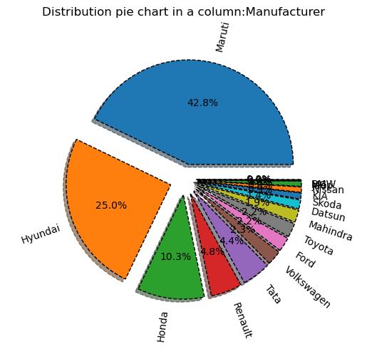

```python
pie_chart('Manufacturer')
```

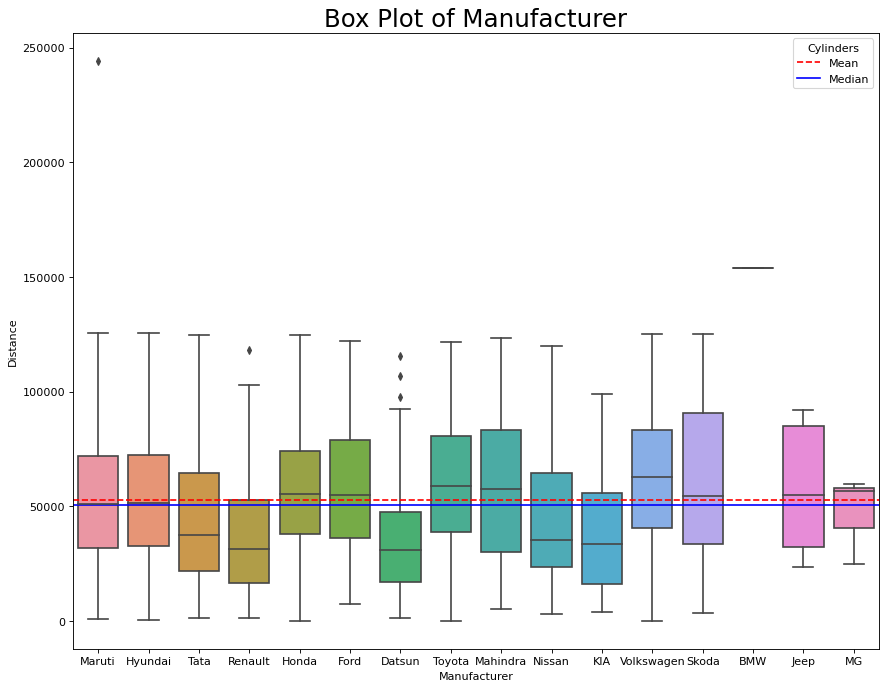

```python
plot_box_plot_('Manufacturer','Distance')# Build box plot by Manufacturer, Distance
```

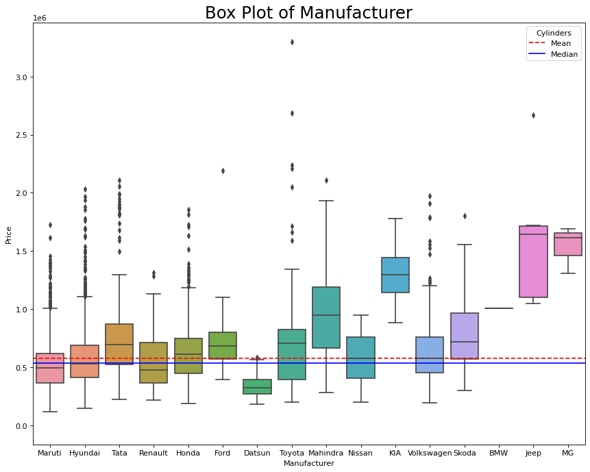

```python
plot_box_plot_('Manufacturer','Price')# Build box plot by Manufacturer, Price
```

Looking at this box plot, we can conclude that the most popular cars on the used market are cars from the middle price category Maruti, Hyundai, Honda, their prices are close to the average and median prices of the entire sample. The distance of these cars is also close to the average for the entire sample. But this fact is not fundamental, since many other manufacturers have similar values. But their average can also be so because they have the most data in the dataset.

Let's check the coefficient of linear correlation between the columns Distance and Price, theoretically, with an increase in the distance, the car should become cheaper, that is, a negative coefficient of linear correlation

```
posx and posy should be finite values
posx and posy should be finite values
```

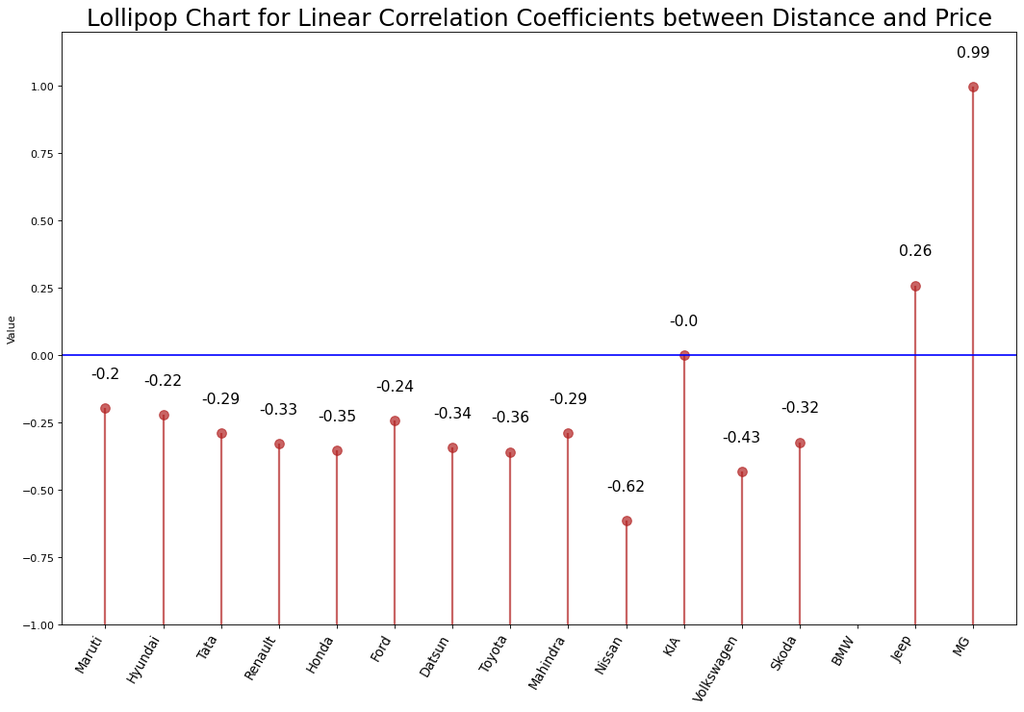

```python
name_column = []
cor = []
for i in data_cars['Manufacturer'].unique():
    #Among the unique values Manufacturer  we calculate the correlation coefficient and put everything in separate arrays
    name_column.append(i)
    cor.append(round(data_cars.loc[data_cars['Manufacturer']==i]['Distance'].corr(data_cars.loc[data_cars['Manufacturer']==i]['Price']),3))

fig, ax = plt.subplots(figsize=(16,10), dpi= 80)
ax.vlines(x=name_column, ymin=-1, ymax=cor, color='firebrick', alpha=0.7, linewidth=2)
ax.scatter(x=name_column, y=cor, s=75, color='firebrick', alpha=0.7)

# Title, Label, Ticks and Ylim
ax.set_title('Lollipop Chart for Linear Correlation Coefficients between Distance and Price', fontdict={'size':22})
ax.set_ylabel('Value')
ax.set_xticks(name_column)
ax.set_xticklabels(name_column, rotation=60, fontdict={'horizontalalignment': 'right', 'size':12})
plt.axhline (y=0, color='blue')
ax.set_ylim(-1, 1.2)

# Annotate
for row in range(len(cor)):
    ax.text(name_column[row], cor[row]+.1, s=round(cor[row], 2), horizontalalignment= 'center', verticalalignment='bottom', fontsize=14)

plt.show()
```

The Maruti company has a linear correlation coefficient closest to 0 (if you do not take into account those that are 0 and higher), this indicates that the cars of this brand lose the least in price, most likely the quality of these cars is higher than the rest presented in this data set

Let's take a closer look at car brands in which the coefficient of linear correlation between distance and price is equal to or higher than 0.

```python
data_cars.loc[data_cars['Manufacturer']=='MG']
```

|  | Year | Distance | Owner | Fuel | Drive | Type | Price | Manufacturer | Name_car | Count |
| --- | --- | --- | --- | --- | --- | --- | --- | --- | --- | --- |
| 4328 | 2020 | 59688 | 1 | PETROL | Automatic | SUV | 1690000 | MG | HECTOR PLUS | 1 |
| 4939 | 2019 | 24618 | 1 | DIESEL | Manual | SUV | 1308000 | MG | HECTOR | 1 |
| 7193 | 2019 | 56561 | 1 | DIESEL | Manual | SUV | 1615000 | MG | HECTOR | 1 |

```python
data_cars.loc[data_cars['Manufacturer']=='Jeep']
```

|  | Year | Distance | Owner | Fuel | Drive | Type | Price | Manufacturer | Name_car | Count |
| --- | --- | --- | --- | --- | --- | --- | --- | --- | --- | --- |
| 2054 | 2019 | 23690 | 1 | PETROL | Automatic | Lux_SUV | 1645000 | Jeep | Compass | 1 |
| 2073 | 2017 | 89464 | 1 | DIESEL | Manual | Lux_SUV | 1103000 | Jeep | Compass | 1 |
| 2937 | 2019 | 23457 | 1 | PETROL | Automatic | Lux_SUV | 1690000 | Jeep | Compass | 1 |
| 4101 | 2017 | 64212 | 1 | DIESEL | Manual | Lux_SUV | 1049000 | Jeep | Compass | 1 |
| 4192 | 2017 | 32038 | 1 | DIESEL | Manual | Lux_SUV | 1084000 | Jeep | Compass | 1 |
| 4241 | 2020 | 52332 | 1 | PETROL | Automatic | Lux_SUV | 1715000 | Jeep | Compass | 1 |
| 5789 | 2016 | 91825 | 1 | DIESEL | Automatic | Lux_SUV | 2666000 | Jeep | GRAND CHEROKEE | 1 |
| 7432 | 2017 | 54857 | 1 | DIESEL | Manual | Lux_SUV | 1146000 | Jeep | Compass | 1 |
| 7742 | 2019 | 84927 | 1 | DIESEL | Automatic | Lux_SUV | 1718000 | Jeep | Compass | 1 |

```python
data_cars.loc[data_cars['Manufacturer']=='KIA']
```

|  | Year | Distance | Owner | Fuel | Drive | Type | Price | Manufacturer | Name_car | Count |
| --- | --- | --- | --- | --- | --- | --- | --- | --- | --- | --- |
| 122 | 2021 | 22542 | 1 | PETROL | Manual | SUV | 1141000 | KIA | SONET | 1 |
| 134 | 2020 | 96537 | 2 | PETROL | Manual | SUV | 906000 | KIA | SELTOS | 1 |
| 275 | 2022 | 5758 | 1 | DIESEL | Automatic | SUV | 1431000 | KIA | SONET | 1 |
| 342 | 2019 | 57179 | 1 | PETROL | Manual | SUV | 1197000 | KIA | SELTOS | 1 |
| 483 | 2021 | 11425 | 1 | PETROL | Manual | SUV | 991000 | KIA | SONET | 1 |
| ... | ... | ... | ... | ... | ... | ... | ... | ... | ... | ... |
| 7415 | 2020 | 21965 | 1 | PETROL | Manual | SUV | 1442000 | KIA | SELTOS | 1 |
| 7445 | 2019 | 24270 | 2 | PETROL | Automatic | SUV | 1485000 | KIA | SELTOS | 1 |
| 7550 | 2021 | 11487 | 1 | PETROL | Manual | SUV | 989000 | KIA | SONET | 1 |
| 7687 | 2019 | 41610 | 1 | PETROL | Automatic | SUV | 1174000 | KIA | SELTOS | 1 |
| 7852 | 2020 | 52138 | 1 | DIESEL | Automatic | SUV | 1227000 | KIA | SONET | 1 |

65 rows × 10 columns

As you can see, these are mostly new cars and their number is very small compared to the entire dataset, so this is a feature of the data collection and not the data itself.

Let's test the hypothesis that the price of Maruti cars is different from the prices of Hyundai cars.

H 0 : prices are equal between two groups; H 1 : The prices for the two groups are not the same .

```python
print('The ratio of the number of Hyundai cars to Maruti =',len(data_cars.loc[data_cars['Manufacturer']=='Hyundai'])/len(data_cars.loc[data_cars['Manufacturer']=='Maruti']))
```

```
The ratio of the number of Hyundai cars to Maruti = 0.5846198660064084
```

As you can see, there is an imbalance in the data, so we will conduct A / B testing with parts of the data from Maruti. That is, we will break Maruti into samples and then test it 100 times

```python
def mann_sample_check(column_1,column_2,num_column):
    #The cycle of splitting into samples and further testing of the hypothesis according to the Man-Whitney test
    P_Val_num = []
    for i in range(100):
        num_samp = len(data_cars.loc[data_cars['Manufacturer']==column_2])
        df = data_cars.loc[data_cars['Manufacturer']==column_1][num_column].sample(num_samp)
        P_Val_num.append(mannwhitneyu(df, data_cars.loc[data_cars['Manufacturer']==column_2][num_column], alternative='two-sided')[1])
    return P_Val_num
```

```python
print('Maximum p-value according to the Mann-Whitney test =',max(mann_sample_check('Maruti','Hyundai','Price')))
```

```
Maximum p-value according to the Mann-Whitney test = 6.577385184932462e-09
```

Since the p-value according to the Mann-Whitney criterion is no more than 0.05, we can reject the null hypothesis of equality, that is, on average, the price of Manufacturer cars is less than the price of Hyundai cars (see Box plot)

Let's test the hypothesis about the equality of distances run between Maruti and Hyundai

```python
check_data = mann_sample_check('Maruti','Hyundai','Distance')
print('Maximum p-value according to the Mann-Whitney test =',max(check_data))
```

```
Maximum p-value according to the Mann-Whitney test = 0.99180640949028
```

```python
check_df = pd.DataFrame(check_data, columns=['p_val'])
print('Number of tests with p-value > 0.05:',len(check_df.loc[check_df['p_val']>0.05]))
```

```
Number of tests with p-value > 0.05: 99
```

It turns out that these brands of cars are the same in terms of mileage

We can conclude that the manufacturer Maruti is more popular Hyundai because it is cheaper

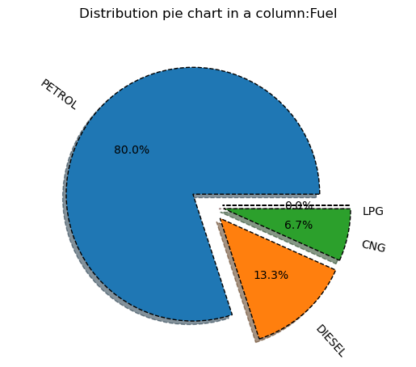

```python
pie_chart('Fuel')
```

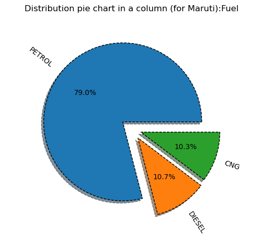

```python
pie_chart_for_Maruti('Fuel')
```

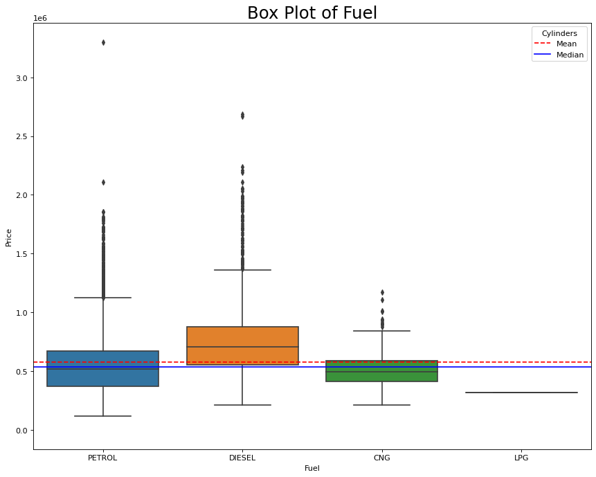

```python
plot_box_plot_by_price('Fuel','Price')
```

Most Expensive Diesel Cars

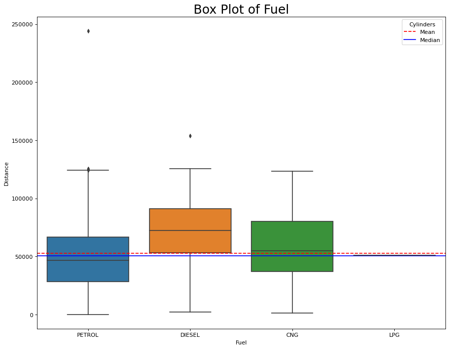

```python
plot_box_plot_by_price('Fuel','Distance')
```

Also cars with diesel fuel have a long distance

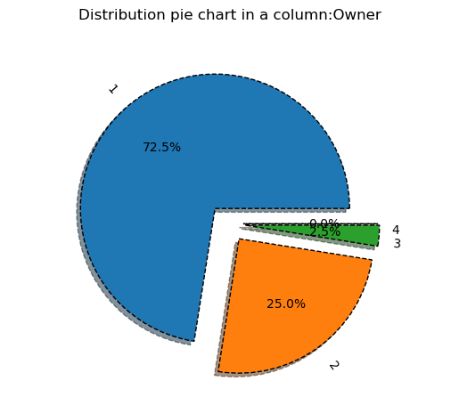

```python
pie_chart('Owner')
```

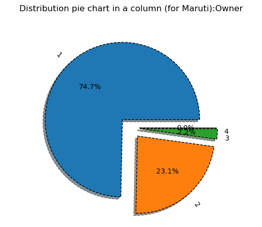

```python
pie_chart_for_Maruti('Owner')
```

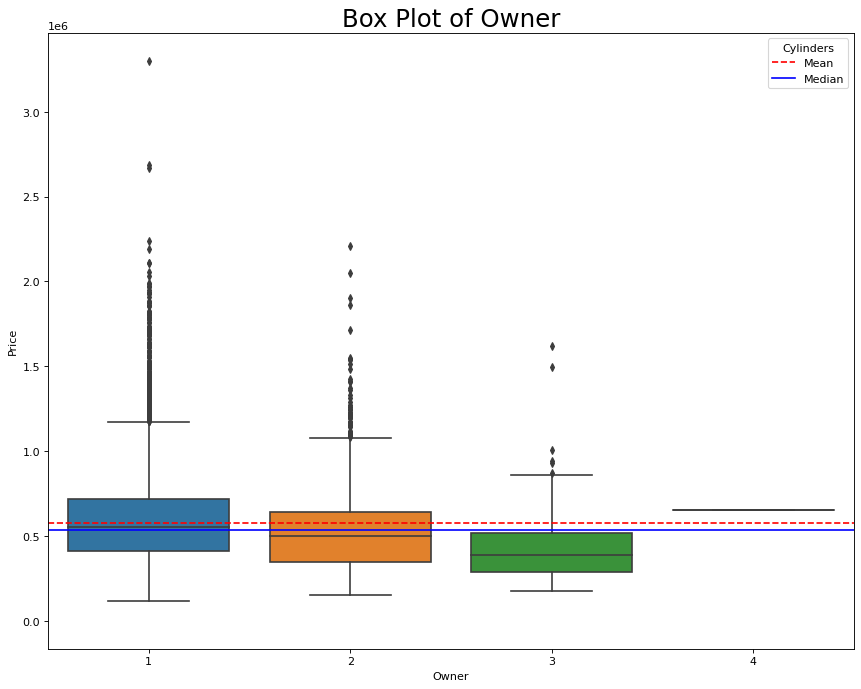

```python
plot_box_plot_by_price('Owner','Price')
```

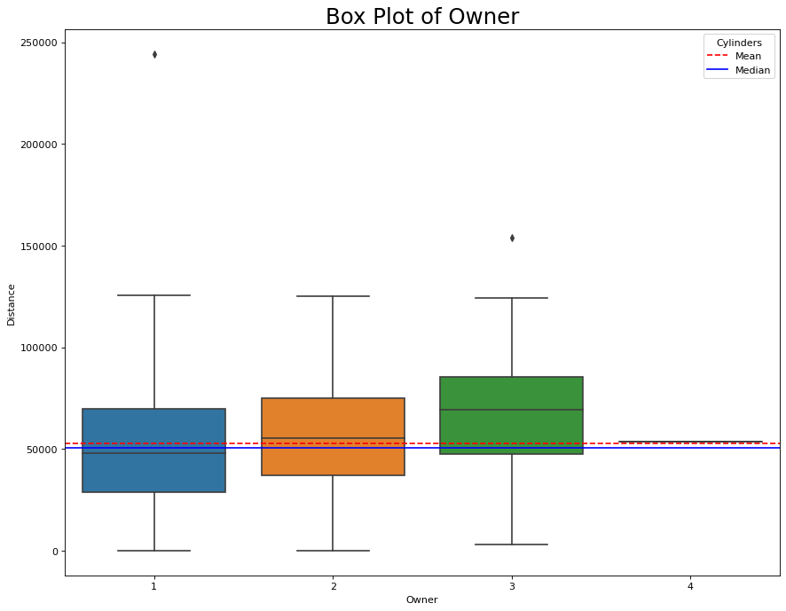

```python
plot_box_plot_by_price('Owner','Distance')
```

Cars with more owners cost less and have more driving distance.

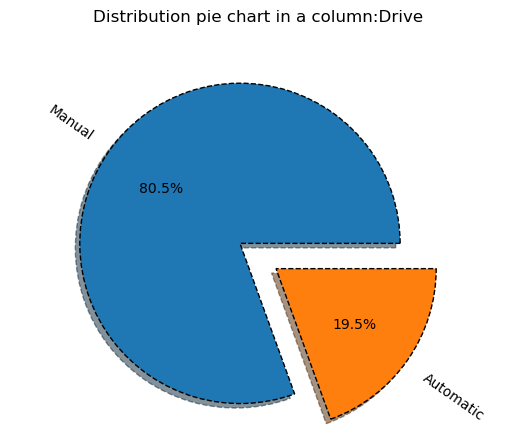

```python
pie_chart('Drive')
```

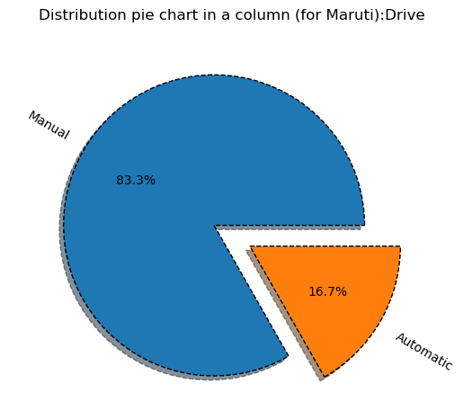

```python
pie_chart_for_Maruti('Drive')
```

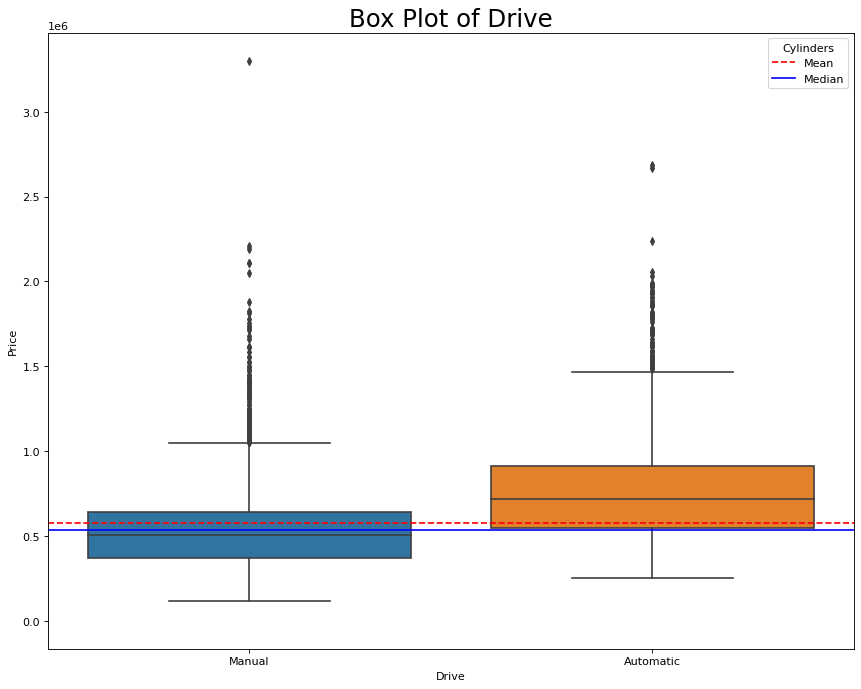

```python
plot_box_plot_by_price('Drive','Price')
```

The most popular transmission in cars is manual, it is also the cheapest.

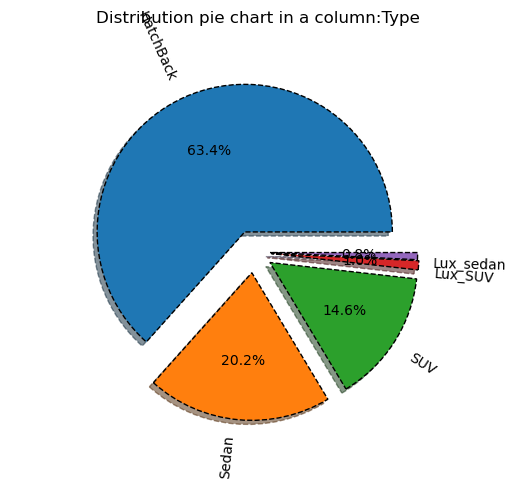

```python
pie_chart('Type')
```

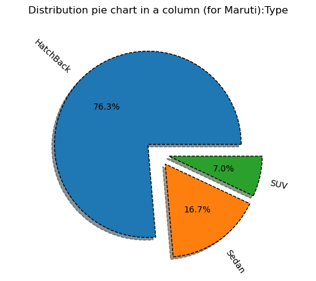

```python
pie_chart_for_Maruti('Type')
```

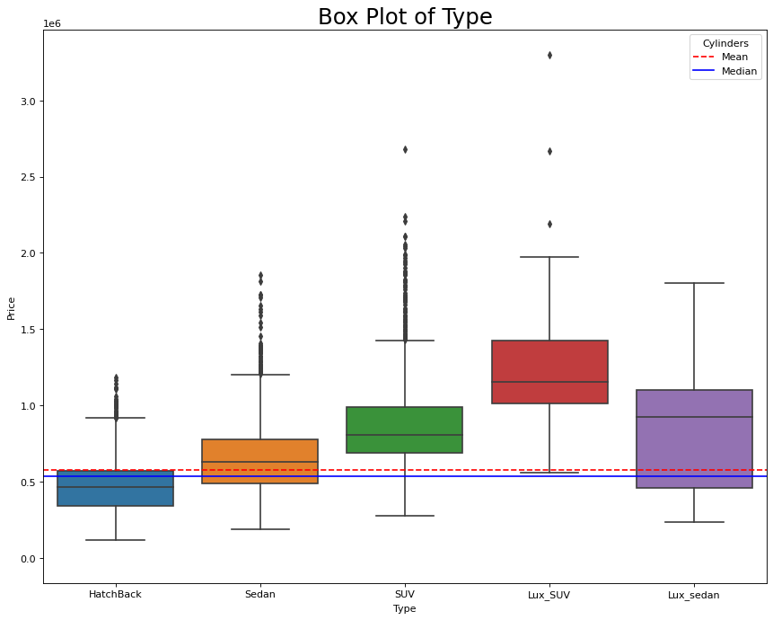

```python
plot_box_plot_by_price('Type','Price')
```

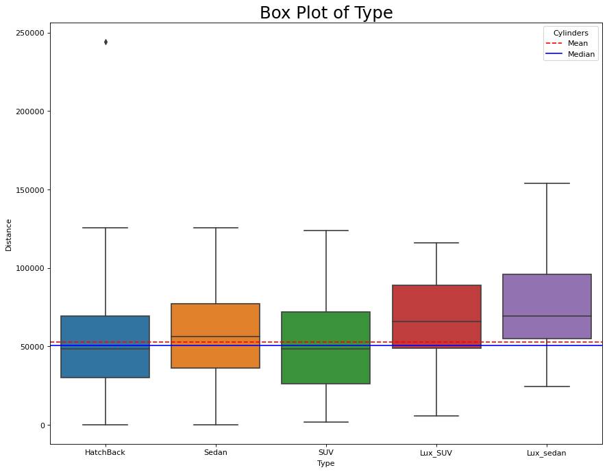

```python
plot_box_plot_by_price('Type','Distance')
```

The most popular type of car is the Hatchback, but also the cheapest

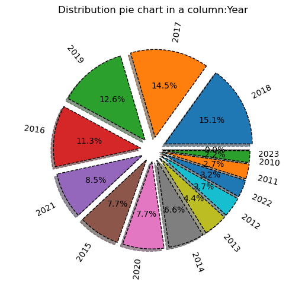

```python
pie_chart('Year')
```

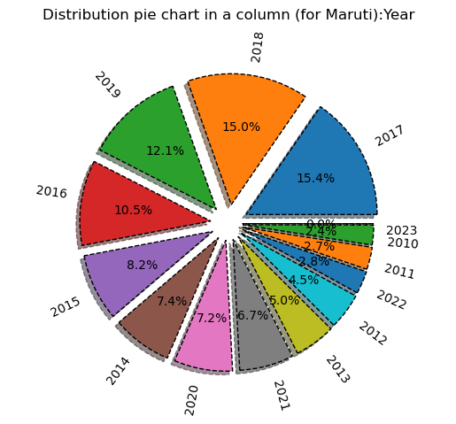

```python
pie_chart_for_Maruti('Year')
```

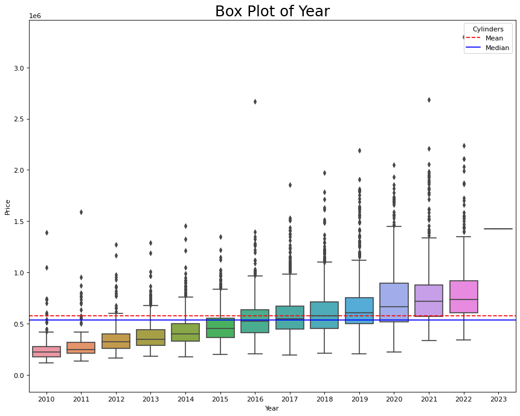

```python
plot_box_plot_by_price('Year','Price')
```

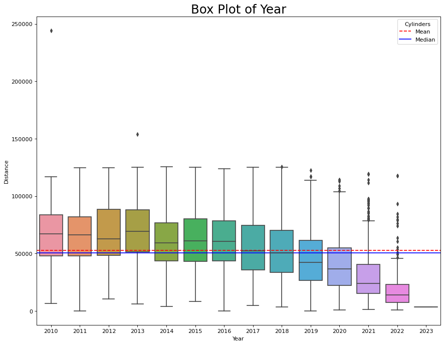

```python
plot_box_plot_by_price('Year','Distance')
```

In general, I tried to compare the entire data set with the data set of the most popular Maruti model and we can say that this model has a larger number of the most popular categories, that is, there is no particular feature because of which this model is so in demand (most likely this is a feature of this car brand but in this data set, it is this brand that is the target for users), we can conclude the car popularity formula: 1) cheapness; 2) manual transmission; 3) body type Hatchback; 4) average distance indicator; 5) one owner; 6) gasoline engine.

## Analysis based on a machine learning model

The price column contains anomalous values, so we will get rid of them to improve the accuracy of the model

```python
print('Percentage of data with a price below 2000000 =',len(data_cars.loc[data_cars['Price']<2000000])/len(data_cars)*100)
```

```
Percentage of data with a price below 2000000 = 99.86272307500312
```

```python
data_cars_for_model = data_cars.loc[data_cars['Price']<2000000]#create a new dataset for the model to work
```

```python
train, test = train_test_split(data_cars_for_model, test_size=0.24, random_state=42)#Divide the sample into training and test
tokenizer = Tokenizer()
for i in ['Fuel','Drive','Type','Manufacturer', 'Name_car']:#the following is a loop of text tokenization into a one-dimensional array
    tokenizer.fit_on_texts(train[i])
    sequences = tokenizer.texts_to_sequences(train[i])
    spis = []
    for u in sequences:
        spis.append(u[0])
    train[i] =  spis
    sequences_2 = tokenizer.texts_to_sequences(test[i])
    spis = []
    for u in sequences_2:
        if len(u)==1:
            spis.append(u[0])
        else:
            spis.append(-1)

    test[i] = spis
```

```python
test.info()
```

```
<class 'pandas.core.frame.DataFrame'>
Int64Index: 1921 entries, 6202 to 4320
Data columns (total 10 columns):
 #   Column        Non-Null Count  Dtype
---  ------        --------------  -----
 0   Year          1921 non-null   int32
 1   Distance      1921 non-null   int64
 2   Owner         1921 non-null   int64
 3   Fuel          1921 non-null   int64
 4   Drive         1921 non-null   int64
 5   Type          1921 non-null   int64
 6   Price         1921 non-null   int64
 7   Manufacturer  1921 non-null   int64
 8   Name_car      1921 non-null   int64
 9   Count         1921 non-null   int64
dtypes: int32(1), int64(9)
memory usage: 157.6 KB
```

```python
train.info()
```

```
<class 'pandas.core.frame.DataFrame'>
Int64Index: 6081 entries, 6070 to 7280
Data columns (total 10 columns):
 #   Column        Non-Null Count  Dtype
---  ------        --------------  -----
 0   Year          6081 non-null   int32
 1   Distance      6081 non-null   int64
 2   Owner         6081 non-null   int64
 3   Fuel          6081 non-null   int64
 4   Drive         6081 non-null   int64
 5   Type          6081 non-null   int64
 6   Price         6081 non-null   int64
 7   Manufacturer  6081 non-null   int64
 8   Name_car      6081 non-null   int64
 9   Count         6081 non-null   int64
dtypes: int32(1), int64(9)
memory usage: 498.8 KB
```

```python
features_train = train.drop(columns='Price')#I separate the target variable from the data so that I can then pass it to the model
target_train = train['Price']
features_test = test.drop(columns='Price')
target_test = test['Price']
```

```python
regr = RandomForestRegressor(max_depth=5, random_state=0,criterion='absolute_error')
regr.fit(features_train, target_train)#train the model with the given parameters
```

```
RandomForestRegressor(criterion='absolute_error', max_depth=5, random_state=0)
```

```python
print('MAE test equel:',mean_absolute_error(target_test, regr.predict(features_test)))
test['mean_check'] = target_train.mean()
print('MAE of mean equel:',mean_absolute_error(test['mean_check'], regr.predict(features_test)))
```

```
MAE test equel: 120381.130661114
MAE of mean equel: 133951.70962738755
```

So we got a model that predicts 10% more accurately than if we just filled in the answers with the average value, this is a bad result, let's find out on which data the model made mistakes most often.

```python
features_train = data_cars_for_model.drop(columns='Price')#I tokenize the words of the entire dataset to train the model on all data
target_train = data_cars_for_model['Price']
tokenizer = Tokenizer()
for i in ['Fuel','Drive','Type','Manufacturer', 'Name_car']:
    tokenizer.fit_on_texts(features_train[i])
    sequences = tokenizer.texts_to_sequences(features_train[i])
    spis = []
    for u in sequences:
        spis.append(u[0])
    features_train[i] =  spis
```

```python
regr = RandomForestRegressor(max_depth=5, random_state=0,criterion='absolute_error')
regr.fit(features_train, target_train)#train the model with the given parameters
```

```
RandomForestRegressor(criterion='absolute_error', max_depth=5, random_state=0)
```

```python
data_cars_for_model.loc[:,'model_res'] = regr.predict(features_train)#write the result of the model in a separate column
```

```python
data_cars_for_model
```

|  | Year | Distance | Owner | Fuel | Drive | Type | Price | Manufacturer | Name_car | Count | model_res |
| --- | --- | --- | --- | --- | --- | --- | --- | --- | --- | --- | --- |
| 0 | 2022 | 3878 | 1 | PETROL | Manual | HatchBack | 514000 | Maruti | S PRESSO | 1 | 513697.75 |
| 1 | 2018 | 32041 | 1 | PETROL | Manual | Sedan | 674000 | Hyundai | Xcent | 1 | 659421.00 |
| 2 | 2021 | 96339 | 1 | DIESEL | Automatic | SUV | 1952000 | Tata | Safari | 1 | 1466758.50 |
| 3 | 2019 | 51718 | 1 | DIESEL | Manual | SUV | 690000 | Maruti | Vitara Brezza | 1 | 874606.75 |
| 4 | 2021 | 19811 | 1 | PETROL | Manual | HatchBack | 526000 | Tata | Tiago | 1 | 513697.75 |
| ... | ... | ... | ... | ... | ... | ... | ... | ... | ... | ... | ... |
| 8010 | 2018 | 11500 | 1 | PETROL | Manual | HatchBack | 292000 | Datsun | Redi Go | 1 | 386475.00 |
| 8011 | 2018 | 73393 | 2 | PETROL | Manual | Sedan | 534000 | Toyota | YARIS | 1 | 578447.75 |
| 8012 | 2016 | 83810 | 2 | PETROL | Manual | Sedan | 424000 | Volkswagen | Ameo | 1 | 578447.75 |
| 8013 | 2019 | 39162 | 1 | PETROL | Automatic | HatchBack | 685000 | Hyundai | GRAND I10 NIOS | 1 | 523347.25 |
| 8014 | 2022 | 82009 | 2 | PETROL | Manual | Sedan | 392000 | Tata | TIGOR | 1 | 573023.25 |

8002 rows × 11 columns

```python
data_cars_for_model.loc[:,'big mistake'] = abs(data_cars_for_model['model_res']-data_cars_for_model['Price'])
data_cars_for_model.loc[:,'big mistake'].describe()#I create a column of the absolute difference between the real price values and those predicted by the model
```

```
count    8.002000e+03
mean     9.862677e+04
std      9.720611e+04
min      2.325000e+01
25%      3.349100e+04
50%      7.236638e+04
75%      1.331538e+05
max      1.027479e+06
Name: big mistake, dtype: float64
```

```python
print('90% of the values in the big mistake column are values <=',data_cars_for_model['big mistake'].quantile(0.9))
```

```
90% of the values in the big mistake column are values <= 208841.15000000023
```

```python
#I create a dataset that includes the largest model errors
search_mistace = data_cars_for_model.loc[data_cars_for_model['big mistake']>data_cars_for_model['big mistake'].quantile(0.9)]
```

```python
search_mistace.describe()
```

|  | Year | Distance | Owner | Price | Count | model_res | big mistake |
| --- | --- | --- | --- | --- | --- | --- | --- |
| count | 801.000000 | 801.000000 | 801.000000 | 8.010000e+02 | 801.0 | 8.010000e+02 | 8.010000e+02 |
| mean | 2018.178527 | 47242.024969 | 1.243446 | 8.635132e+05 | 1.0 | 7.484645e+05 | 3.166065e+05 |
| std | 2.784661 | 28657.397281 | 0.473719 | 4.352955e+05 | 0.0 | 2.464248e+05 | 1.255870e+05 |
| min | 2010.000000 | 1675.000000 | 1.000000 | 1.900000e+05 | 1.0 | 3.810750e+05 | 2.088840e+05 |
| 25% | 2017.000000 | 24060.000000 | 1.000000 | 4.970000e+05 | 1.0 | 5.730232e+05 | 2.341672e+05 |
| 50% | 2019.000000 | 42166.000000 | 1.000000 | 8.060000e+05 | 1.0 | 6.810708e+05 | 2.724992e+05 |
| 75% | 2020.000000 | 66790.000000 | 1.000000 | 1.171000e+06 | 1.0 | 9.104168e+05 | 3.465098e+05 |
| max | 2023.000000 | 153870.000000 | 3.000000 | 1.989000e+06 | 1.0 | 1.628400e+06 | 1.027479e+06 |

```python
data_cars.describe()
```

|  | Year | Distance | Owner | Price | Count |
| --- | --- | --- | --- | --- | --- |
| count | 8013.000000 | 8013.000000 | 8013.000000 | 8.013000e+03 | 8013.0 |
| mean | 2016.995008 | 52511.619743 | 1.300012 | 5.748318e+05 | 1.0 |
| std | 2.861633 | 27319.173575 | 0.510593 | 2.651001e+05 | 0.0 |
| min | 2010.000000 | 0.000000 | 1.000000 | 1.190000e+05 | 1.0 |
| 25% | 2015.000000 | 30732.000000 | 1.000000 | 3.930000e+05 | 1.0 |
| 50% | 2017.000000 | 50359.000000 | 1.000000 | 5.350000e+05 | 1.0 |
| 75% | 2019.000000 | 71761.000000 | 2.000000 | 6.980000e+05 | 1.0 |
| max | 2023.000000 | 244253.000000 | 4.000000 | 3.300000e+06 | 1.0 |

```python
data_cars['Name_car'].value_counts().head(10)
```

```
Swift          593
Grand i10      451
Baleno         430
Elite i20      381
Wagon R 1 0    362
City           307
Celerio        245
Kwid           229
Alto 800       226
Amaze          205
Name: Name_car, dtype: int64
```

```python
search_mistace['Name_car'].value_counts().head(10)
```

```
City           65
Swift Dzire    47
Amaze          39
Verna          37
SELTOS         33
Creta          32
Dzire          31
Ciaz           30
TRIBER         30
Swift          27
Name: Name_car, dtype: int64
```

Most often, the model is mistaken on the data of such cars as City, Swift Dzire, Amaze. The most popular cars are Swift, Grand i10, Baleno, Elite i20.

We remove the columns that are the hardest to predict in order to retrain the model.

```python
data_cars_for_model = data_cars_for_model.drop(search_mistace.index)#remove the columns
data_cars_for_model
```

|  | Year | Distance | Owner | Fuel | Drive | Type | Price | Manufacturer | Name_car | Count | model_res | big mistake |
| --- | --- | --- | --- | --- | --- | --- | --- | --- | --- | --- | --- | --- |
| 0 | 2022 | 3878 | 1 | PETROL | Manual | HatchBack | 514000 | Maruti | S PRESSO | 1 | 513697.75 | 302.25 |
| 1 | 2018 | 32041 | 1 | PETROL | Manual | Sedan | 674000 | Hyundai | Xcent | 1 | 659421.00 | 14579.00 |
| 3 | 2019 | 51718 | 1 | DIESEL | Manual | SUV | 690000 | Maruti | Vitara Brezza | 1 | 874606.75 | 184606.75 |
| 4 | 2021 | 19811 | 1 | PETROL | Manual | HatchBack | 526000 | Tata | Tiago | 1 | 513697.75 | 12302.25 |
| 5 | 2017 | 70129 | 1 | PETROL | Manual | HatchBack | 552000 | Maruti | Swift | 1 | 468617.25 | 83382.75 |
| ... | ... | ... | ... | ... | ... | ... | ... | ... | ... | ... | ... | ... |
| 8010 | 2018 | 11500 | 1 | PETROL | Manual | HatchBack | 292000 | Datsun | Redi Go | 1 | 386475.00 | 94475.00 |
| 8011 | 2018 | 73393 | 2 | PETROL | Manual | Sedan | 534000 | Toyota | YARIS | 1 | 578447.75 | 44447.75 |
| 8012 | 2016 | 83810 | 2 | PETROL | Manual | Sedan | 424000 | Volkswagen | Ameo | 1 | 578447.75 | 154447.75 |
| 8013 | 2019 | 39162 | 1 | PETROL | Automatic | HatchBack | 685000 | Hyundai | GRAND I10 NIOS | 1 | 523347.25 | 161652.75 |
| 8014 | 2022 | 82009 | 2 | PETROL | Manual | Sedan | 392000 | Tata | TIGOR | 1 | 573023.25 | 181023.25 |

7201 rows × 12 columns

```python
data_cars_for_model = data_cars_for_model.drop(columns=['model_res','big mistake'])#remove the columns
data_cars_for_model
```

|  | Year | Distance | Owner | Fuel | Drive | Type | Price | Manufacturer | Name_car | Count |
| --- | --- | --- | --- | --- | --- | --- | --- | --- | --- | --- |
| 0 | 2022 | 3878 | 1 | PETROL | Manual | HatchBack | 514000 | Maruti | S PRESSO | 1 |
| 1 | 2018 | 32041 | 1 | PETROL | Manual | Sedan | 674000 | Hyundai | Xcent | 1 |
| 3 | 2019 | 51718 | 1 | DIESEL | Manual | SUV | 690000 | Maruti | Vitara Brezza | 1 |
| 4 | 2021 | 19811 | 1 | PETROL | Manual | HatchBack | 526000 | Tata | Tiago | 1 |
| 5 | 2017 | 70129 | 1 | PETROL | Manual | HatchBack | 552000 | Maruti | Swift | 1 |
| ... | ... | ... | ... | ... | ... | ... | ... | ... | ... | ... |
| 8010 | 2018 | 11500 | 1 | PETROL | Manual | HatchBack | 292000 | Datsun | Redi Go | 1 |
| 8011 | 2018 | 73393 | 2 | PETROL | Manual | Sedan | 534000 | Toyota | YARIS | 1 |
| 8012 | 2016 | 83810 | 2 | PETROL | Manual | Sedan | 424000 | Volkswagen | Ameo | 1 |
| 8013 | 2019 | 39162 | 1 | PETROL | Automatic | HatchBack | 685000 | Hyundai | GRAND I10 NIOS | 1 |
| 8014 | 2022 | 82009 | 2 | PETROL | Manual | Sedan | 392000 | Tata | TIGOR | 1 |

7201 rows × 10 columns

```python
train, test = train_test_split(data_cars_for_model, test_size=0.24, random_state=42)
tokenizer = Tokenizer()
for i in ['Fuel','Drive','Type','Manufacturer', 'Name_car']:
    tokenizer.fit_on_texts(train[i])
    sequences = tokenizer.texts_to_sequences(train[i])
    spis = []
    for u in sequences:
        spis.append(u[0])
    train[i] =  spis
    sequences_2 = tokenizer.texts_to_sequences(test[i])
    spis = []
    for u in sequences_2:
        if len(u)==1:
            spis.append(u[0])
        else:
            spis.append(-1)

    test[i] = spis
features_train = train.drop(columns='Price')
target_train = train['Price']
features_test = test.drop(columns='Price')
target_test = test['Price']
```

```python
regr = RandomForestRegressor(max_depth=5, random_state=0,criterion='absolute_error')
regr.fit(features_train, target_train)
```

```
RandomForestRegressor(criterion='absolute_error', max_depth=5, random_state=0)
```

```python
print('MAE test equel:',mean_absolute_error(target_test, regr.predict(features_test)))
test['mean_check'] = target_train.mean()
print('MAE of mean equel:',mean_absolute_error(test['mean_check'], regr.predict(features_test)))
```

```
MAE test equel: 92277.15991902835
MAE of mean equel: 115045.57274670736
```

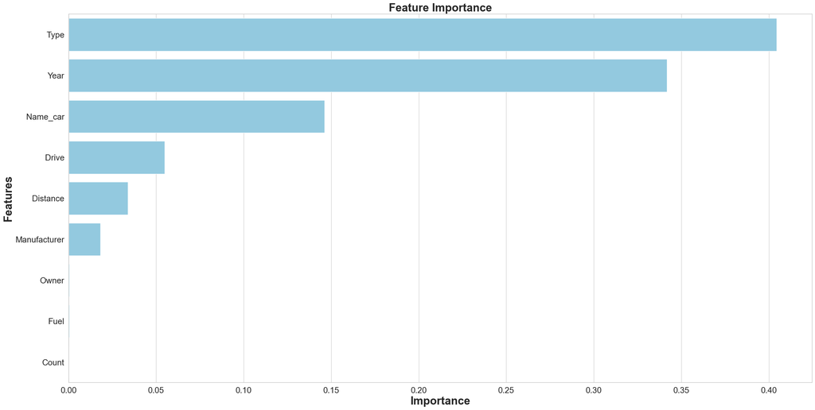

```
None
```

|  | Features | Gini-Importance |
| --- | --- | --- |
| 0 | Type | 0.404469 |
| 1 | Year | 0.341800 |
| 2 | Name_car | 0.146157 |
| 3 | Drive | 0.054913 |
| 4 | Distance | 0.033855 |
| 5 | Manufacturer | 0.018061 |
| 6 | Owner | 0.000404 |
| 7 | Fuel | 0.000340 |
| 8 | Count | 0.000000 |

```python
#visualization and quantification of feature importance indicators by referring to the feature_importances_ attribute
feats = {}
for feature, importance in zip(features_test.columns, regr.feature_importances_):
    feats[feature] = importance
importances = pd.DataFrame.from_dict(feats, orient='index').rename(columns={0: 'Gini-Importance'})
importances = importances.sort_values(by='Gini-Importance', ascending=False)
importances = importances.reset_index()
importances = importances.rename(columns={'index': 'Features'})
sns.set(font_scale = 5)
sns.set(style="whitegrid", color_codes=True, font_scale = 1.7)
fig, ax = plt.subplots()
fig.set_size_inches(30,15)
sns.barplot(x=importances['Gini-Importance'], y=importances['Features'], data=importances, color='skyblue')
plt.xlabel('Importance', fontsize=25, weight = 'bold')
plt.ylabel('Features', fontsize=25, weight = 'bold')
plt.title('Feature Importance', fontsize=25, weight = 'bold')
display(plt.show())
display(importances)
```

So, to a greater extent, the price of a car depends on its type, year of manufacture and the car itself (its design and design features)

## Conclusion

I analyzed the dataset from the site for sales of used cars cars_24. In this data, the most popular brand is Maruti and the Swift model. The used car popularity formula: 1) cheapness; 2) manual transmission; 3) body type Hatchback; 4) average distance indicator; 5) one owner; 6) gasoline engine. The price of a used car depends on its type, year of manufacture and the car itself (its design and design features). I am not an expert in the automotive industry and do not know what is special about cars like City, Swift Dzire, Amaze, these cars were unpredictably overpriced compared to the rest. After doing A/B testing, I compared the two most popular manufacturers in this dataset and the most popular has a lower price.